# Programming with Python

## Basic data processing and analysis using python libraries: Pandas

#### Asst. Prof Roshan Tandukar

# Pandas

It is a package useful for data analysis and manipulation.

Pandas provide an easy way to create, manipulate and wrangle the data.

Pandas provide powerful and easy-to-use data structures, as well as the means to quickly perform operations on these structures.

### DATA STRUCTURE IN PANDAS

Pandas deals with 3 data structure

1. Series
2. Data Frame
3. Panel

### Series

It is a one-dimensional array like structure with homogeneous data, which can be used to handle and manipulate data.

What makes it special is its index attribute, which has incredible functionality and is heavily mutable.

Syntax:  
obj=pandas.Series (data, index=idx (optional))

```python
import pandas as pd
import numpy as np
arr=np.array([10,15,18,22])
s = pd.Series(arr)
print(s)
```

```
0    10
1    15
2    18
3    22
dtype: int32
```

```python
import pandas as pd
import numpy as np
arr=np.array(['a','b','c','d'])
s=pd.Series(arr, index=['first','second','third','fourth'])
print(s)
```

```
first     a
second    b
third     c
fourth    d
dtype: object
```

### Creating a series from Scalar value

```python
import pandas as pd
s=pd.Series(10,index=[1,2,3,4,5])
s
```

```
1    10
2    10
3    10
4    10
5    10
dtype: int64
```

### Creating a series from a Dictionary

```python
d={'Nme':'Ram','Level':'Masters','Age':25}
s=pd.Series(d)
s
```

```
Nme          Ram
Level    Masters
Age           25
dtype: object
```

### Arithmetics in Series

```python
import pandas as pd
s=pd.Series([1,2,3,4,5])
print(s+2)
```

```
0    3
1    4
2    5
3    6
4    7
dtype: int64
```

```python
s*2
```

```
0     2
1     4
2     6
3     8
4    10
dtype: int64
```

```python
s**2
```

```
0     1
1     4
2     9
3    16
4    25
dtype: int64
```

```python
s
```

```
0    1
1    2
2    3
3    4
4    5
dtype: int64
```

```python
s1=pd.Series([4,5,6,7,8,9,10])
s1
```

```
0     4
1     5
2     6
3     7
4     8
5     9
6    10
dtype: int64
```

```python
s+s1
```

```
0     5.0
1     7.0
2     9.0
3    11.0
4    13.0
5     NaN
6     NaN
dtype: float64
```

```python
s2=pd.Series([1,2,3,4],index=[0,4,5,2])
s2
```

```
0    1
4    2
5    3
2    4
dtype: int64
```

```python
s+s2
```

```
0    2.0
1    NaN
2    7.0
3    NaN
4    7.0
5    NaN
dtype: float64
```

### Head and Tail Functions in Series

```python
arr=np.arange(12)
arr
```

```
array([ 0,  1,  2,  3,  4,  5,  6,  7,  8,  9, 10, 11])
```

```python
s=pd.Series(arr)
s.head() #to access the first 5 rows of a series
```

```
0    0
1    1
2    2
3    3
4    4
dtype: int32
```

```python
s.head(2)
```

```
0    0
1    1
dtype: int32
```

```python
s.head(10)
```

```
0    0
1    1
2    2
3    3
4    4
5    5
6    6
7    7
8    8
9    9
dtype: int32
```

```python
s.tail() #to access the last 5 rows of a series
```

```
7      7
8      8
9      9
10    10
11    11
dtype: int32
```

```python
s.tail(3)
```

```
9      9
10    10
11    11
dtype: int32
```

### Selection in Series

Series provides index label loc, iloc and [] to access rows and columns

### 1. loc index label

Syntax: sname.loc[StartRange: StopRange]

```python
s.loc[2:4]
```

```
2    2
3    3
4    4
dtype: int32
```

```python
s.loc[-5:-1]
```

```
Series([], dtype: int32)
```

```python
s.loc[:]
```

```
0      0
1      1
2      2
3      3
4      4
5      5
6      6
7      7
8      8
9      9
10    10
11    11
dtype: int32
```

### 2. Selection Using iloc index label

Syntax:-sname.iloc[StartRange : StopRange]

```python
s.iloc[3:5]
```

```
3    3
4    4
dtype: int32
```

### 3. Selection Using [ ]

```python
s[2:5]
```

```
2    2
3    3
4    4
dtype: int32
```

```python
s[-1:-5]
```

```
Series([], dtype: int32)
```

```python
s[-5:-1]
```

```
7      7
8      8
9      9
10    10
dtype: int32
```

### Slicing in Series

Slicing is a way to retrieve subsets of data from a pandas object.

A slice object syntax is  
– snameME [start:end: step]

```python
s[1:8:2]
```

```
1    1
3    3
5    5
7    7
dtype: int32
```

### DataFrame

It is a two-dimensional object that is useful in representing data in the form of rows and columns.

It is similar to a spreadsheet or an SQL table.

This is the most commonly used pandas object.

Once we store the data into the Dataframe, we can perform various operations that are useful in analyzing and understanding the data.

### Properties of a Dataframe

1. A Dataframe has axes (indices):

➢ Row index (axis=0)  
➢ Column index (axes=1) 2. It is similar to a spreadsheet , whose row index is called index and column index is called column name. 3. A Dataframe contains Heterogeneous data. 4. A Dataframe Size is Mutable. 5. A Dataframe Data is Mutable.

### Creation of DataFrame

A data frame can be created using any of the following:

1. Series
2. Lists
3. Dictionary
4. A numpy 2D array

```python
import pandas as pd
df=pd.DataFrame() #creating empty dataframe
print(df)
```

```
Empty DataFrame
Columns: []
Index: []
```

```python
#Dataframe from Series
import pandas as pd
s = pd.Series(['a','b','c','d'])
df=pd.DataFrame(s)
print(df)
```

```
   0
0  a
1  b
2  c
3  d
```

```python
#DataFrame from Dictionary of Series
name=pd.Series(['Ram','Hari','Gita'])
level=pd.Series(['Bachelor','Masters','Masters'])
dic={'Name':name,'Level':level}
df=pd.DataFrame(dic)
print(df)
```

```
   Name     Level
0   Ram  Bachelor
1  Hari   Masters
2  Gita   Masters
```

```python
#DataFrame from List of Dictionaries
l=[{'fname':'Ram','lname':'Thapa'},
   {'fname':'Gita','lname':'Rai'},
   {'fname':'Sagar','lname':'Mainali'}]
df1=pd.DataFrame(l)
print(df1)
df1
```

```
   fname    lname
0    Ram    Thapa
1   Gita      Rai
2  Sagar  Mainali
```

|  | fname | lname |
| --- | --- | --- |
| 0 | Ram | Thapa |
| 1 | Gita | Rai |
| 2 | Sagar | Mainali |

### DataFrame Attributes

When we create an object of a DataFrame then all information related to it like size, datatype etc can be accessed by attributes.  
Syntax: DataFrame.attribute_name

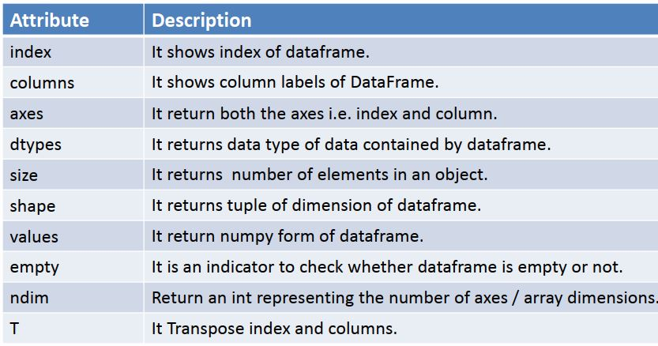

### Select operation in data frame: Subsetting

1. Select specific columns from a DataFrame

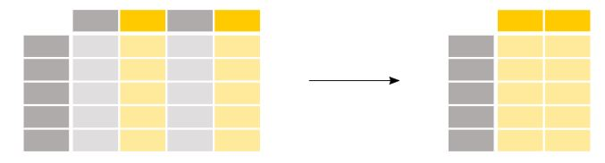

### Select operation in data frame: Subsetting

To access the column data ,we can mention the column name as subscript.  
e.g. df[empid]

This can also be done by using df.empid.

To access multiple columns we can write as df[ [col1, col2,---] ]

```python
data={'id':[101,102,103,104,105],
     'name':['Ram','Sita','Sudha','Anup','Biplov'],
     'level':['Masters','Bachelor','PhD','Masters','Masters']}
df=pd.DataFrame(data)
df
```

|  | id | name | level |
| --- | --- | --- | --- |
| 0 | 101 | Ram | Masters |
| 1 | 102 | Sita | Bachelor |
| 2 | 103 | Sudha | PhD |
| 3 | 104 | Anup | Masters |
| 4 | 105 | Biplov | Masters |

```python
df.id
```

```
0    101
1    102
2    103
3    104
4    105
Name: id, dtype: int64
```

```python
df['id']
```

```
0    101
1    102
2    103
3    104
4    105
Name: id, dtype: int64
```

```python
df[['id','name']]
```

|  | id | name |
| --- | --- | --- |
| 0 | 101 | Ram |
| 1 | 102 | Sita |
| 2 | 103 | Sudha |
| 3 | 104 | Anup |
| 4 | 105 | Biplov |

### Select operation in data frame: Subsetting

2. Select specific rows and columns from a DataFrame

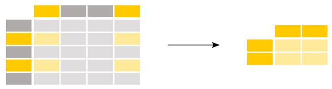

```python
df.head()
```

|  | id | name | level |
| --- | --- | --- | --- |
| 0 | 101 | Ram | Masters |
| 1 | 102 | Sita | Bachelor |
| 2 | 103 | Sudha | PhD |
| 3 | 104 | Anup | Masters |
| 4 | 105 | Biplov | Masters |

```python
df.head(3)
```

|  | id | name | level |
| --- | --- | --- | --- |
| 0 | 101 | Ram | Masters |
| 1 | 102 | Sita | Bachelor |
| 2 | 103 | Sudha | PhD |

```python
df.tail(3)
```

|  | id | name | level |
| --- | --- | --- | --- |
| 2 | 103 | Sudha | PhD |
| 3 | 104 | Anup | Masters |
| 4 | 105 | Biplov | Masters |

### To Add & Rename a column in data frame

```python
df['salary']=50000
df
```

|  | id | name | level | salary |
| --- | --- | --- | --- | --- |
| 0 | 101 | Ram | Masters | 50000 |
| 1 | 102 | Sita | Bachelor | 50000 |
| 2 | 103 | Sudha | PhD | 50000 |
| 3 | 104 | Anup | Masters | 50000 |
| 4 | 105 | Biplov | Masters | 50000 |

```python
df['salary']=[25000,15000,20000,34000,23000]
df
```

|  | id | name | level | salary |
| --- | --- | --- | --- | --- |
| 0 | 101 | Ram | Masters | 25000 |
| 1 | 102 | Sita | Bachelor | 15000 |
| 2 | 103 | Sudha | PhD | 20000 |
| 3 | 104 | Anup | Masters | 34000 |
| 4 | 105 | Biplov | Masters | 23000 |

##### Create two Series: [10,20,30,40,50] and [2,4,6,8,10] and perform the following tasks:

1. Create a dataframe wih the series
2. Add a new column sum.

```python
import pandas as pd
s1=pd.Series([10,20,30,40,50],name='Domain')
s2=pd.Series([2,4,6,8,10])
df=pd.DataFrame(s1)
df['value']=s2
df
```

|  | Domain | value |
| --- | --- | --- |
| 0 | 10 | 2 |
| 1 | 20 | 4 |
| 2 | 30 | 6 |
| 3 | 40 | 8 |
| 4 | 50 | 10 |

```python
import pandas as pd
s1=pd.Series([10,20,30,40,50])
s2=pd.Series([2,4,6,8,10])
df=pd.DataFrame({'domain':s1,'value':s2})
df
```

|  | domain | value |
| --- | --- | --- |
| 0 | 10 | 2 |
| 1 | 20 | 4 |
| 2 | 30 | 6 |
| 3 | 40 | 8 |
| 4 | 50 | 10 |

```python
df['sum']=df['domain']+df['value']
df
```

|  | domain | value | sum |
| --- | --- | --- | --- |
| 0 | 10 | 2 | 12 |
| 1 | 20 | 4 | 24 |
| 2 | 30 | 6 | 36 |
| 3 | 40 | 8 | 48 |
| 4 | 50 | 10 | 60 |

### To Delete a Column in data frame

We can delete the column from a data frame by using any of the the following –

1. del
2. pop()
3. drop()

```python
del df['sum']
df
```

|  | domain | value |
| --- | --- | --- |
| 0 | 10 | 2 |
| 1 | 20 | 4 |
| 2 | 30 | 6 |
| 3 | 40 | 8 |
| 4 | 50 | 10 |

```python
df.pop('value')
df
```

|  | domain |
| --- | --- |
| 0 | 10 |
| 1 | 20 |
| 2 | 30 |
| 3 | 40 |
| 4 | 50 |

```python
new=df.drop('domain',axis='columns')
new
```

[output not shown]

### Reading csv files

```python
import pandas as pd
df=pd.read_csv("info.csv")
print(df)
```

```
   Unnamed: 0   id  name address  age
0           0  103  hari     ktm   32
1           1  104  rita     brt   24
```

```python
data=[{'id':103,'name':'ram','address':'ktm','age':32},
   {'id':104,'name':'sam','address':'brt','age':24}]
df1=pd.DataFrame(data)
df1.to_csv('D:\TU\MCA\Python\info.csv',mode='a',index=False,header=False)
print(df1)
data
```

```
    id name address  age
0  103  ram     ktm   32
1  104  sam     brt   24
```

```
[{'id': 103, 'name': 'ram', 'address': 'ktm', 'age': 32},
 {'id': 104, 'name': 'sam', 'address': 'brt', 'age': 24}]
```

### Reading JSON Files

JavaScript Object Notation (JSON) is a data format that stores data in a human-readable form.

While it can technically be used for storage, JSON files are primarily used for serialization and information exchange between a client and server.

```python
data
```

```
[{'id': 103, 'name': 'ram', 'address': 'ktm', 'age': 32},
 {'id': 104, 'name': 'sam', 'address': 'brt', 'age': 24}]
```

```python
df.to_json('student.json')
```

```python
d=pd.read_json('student.json')
d
```

|  | Unnamed: 0 | id | name | address | age |
| --- | --- | --- | --- | --- | --- |
| 0 | 0 | 103 | hari | ktm | 32 |
| 1 | 1 | 104 | rita | brt | 24 |

### Reading json files remotely

```python
import pandas as pd
iris_data = pd.read_json("https://raw.githubusercontent.com/domoritz/maps/master/data/iris.json")
iris_data.head()
```

|  | sepalLength | sepalWidth | petalLength | petalWidth | species |
| --- | --- | --- | --- | --- | --- |
| 0 | 5.1 | 3.5 | 1.4 | 0.2 | setosa |
| 1 | 4.9 | 3.0 | 1.4 | 0.2 | setosa |
| 2 | 4.7 | 3.2 | 1.3 | 0.2 | setosa |
| 3 | 4.6 | 3.1 | 1.5 | 0.2 | setosa |
| 4 | 5.0 | 3.6 | 1.4 | 0.2 | setosa |

### Merge operation in data frame

Two DataFrames might hold different kinds of information about the same entity and linked by some common feature/column.

To join these DataFrames, pandas provides multiple functions like merge(), join() etc.

```python
import pandas as pd
dict1={'id':[1,2,3,4,5],
     'value':['A','B','C','D','E']}
dict2={'id':[2,4,6,8],
     'value':['A','B','C','D']}
df1=pd.DataFrame(dict1)
df2=pd.DataFrame(dict2)
pd.concat([df1,df2])
```

|  | id | value |
| --- | --- | --- |
| 0 | 1 | A |
| 1 | 2 | B |
| 2 | 3 | C |
| 3 | 4 | D |
| 4 | 5 | E |
| 0 | 2 | A |
| 1 | 4 | B |
| 2 | 6 | C |
| 3 | 8 | D |

```python
pd.merge(df1,df2,on='id')
```

|  | id | value_x | value_y |
| --- | --- | --- | --- |
| 0 | 2 | B | A |
| 1 | 4 | D | B |

```python
df1.join(df2,lsuffix='__val1',rsuffix='__val2')
```

|  | id__val1 | value__val1 | id__val2 | value__val2 |
| --- | --- | --- | --- | --- |
| 0 | 1 | A | 2.0 | A |
| 1 | 2 | B | 4.0 | B |
| 2 | 3 | C | 6.0 | C |
| 3 | 4 | D | 8.0 | D |
| 4 | 5 | E | NaN | NaN |

### Join operation in data frame

### Inner Join

The inner join produce only those records that match in both the data frame. You have to pass inner in how argument inside merge() function.

```python
import pandas as pd
dict1={'id':[1,2,3,4,5],
     'value':['A','B','C','D','E']}
dict2={'id':[2,4,6,8],
     'value':['A','B','C','D']}
df1=pd.DataFrame(dict1)
df2=pd.DataFrame(dict2)
df=pd.merge(df1,df2,on='id',how='inner')
df
```

|  | id | value_x | value_y |
| --- | --- | --- | --- |
| 0 | 2 | B | A |
| 1 | 4 | D | B |

### Left Join

The left join produce a complete set of records from data frame A(Left side Data Frame) with the matching records (where available) in data frame B( Right side data frame).

```python
df=pd.merge(df1,df2,on='id',how='left')
df
```

|  | id | value_x | value_y |
| --- | --- | --- | --- |
| 0 | 1 | A | NaN |
| 1 | 2 | B | A |
| 2 | 3 | C | NaN |
| 3 | 4 | D | B |
| 4 | 5 | E | NaN |

### RightJoin

The right join produce a complete set of records from data frame B(Right side Data Frame) with the matching records (where available) in data frame A( Left side data frame).

You have to pass right in how argument inside merge() function.

```python
df=pd.merge(df1,df2,on='id',how='right')
df
```

|  | id | value_x | value_y |
| --- | --- | --- | --- |
| 0 | 2 | B | A |
| 1 | 4 | D | B |
| 2 | 6 | NaN | C |
| 3 | 8 | NaN | D |

### Full Outer Join

full outer join combines the results of both the left and the right outer joins.

The joined data frame will contain all records from both the data frames and fill in NaNs for missing matches on either side.

You can perform a full outer join by specifying the how argument as outer in merge() function.

```python
df=pd.merge(df1,df2,left_on='id',right_on='id',how='outer',suffixes=('__left','__right'))
df
```

|  | id | value__left | value__right |
| --- | --- | --- | --- |
| 0 | 1 | A | NaN |
| 1 | 2 | B | A |
| 2 | 3 | C | NaN |
| 3 | 4 | D | B |
| 4 | 5 | E | NaN |
| 5 | 6 | NaN | C |
| 6 | 8 | NaN | D |

### Joining on Index

Sometimes you have to perform the join on the indexes or the row labels.

For that you have to specify right_index( for the indexes of the right data frame ) and left_index( for the indexes of left data frame) as True.

```python
df=pd.merge(df1,df2,right_index=True, left_index=True)
df
```

|  | id_x | value_x | id_y | value_y |
| --- | --- | --- | --- | --- |
| 0 | 1 | A | 2 | A |
| 1 | 2 | B | 4 | B |
| 2 | 3 | C | 6 | C |
| 3 | 4 | D | 8 | D |

### Handling Missing Values

In Pandas, missing values, often represented as NaN (Not a Number), can cause problems during data processing and analysis.

These gaps in data can lead to incorrect analysis and misleading conclusions.

Pandas provides a host of functions like dropna(), fillna() and combine_first() to handle missing values.

```python
import numpy as np
data={'a':[1,5,3,2,np.nan],
     'b':[3,np.nan,4,np.nan,1],
     'c':[np.nan,np.nan, 2,6,2]}
df=pd.DataFrame(data)
df
```

|  | a | b | c |
| --- | --- | --- | --- |
| 0 | 1.0 | 3.0 | NaN |
| 1 | 5.0 | NaN | NaN |
| 2 | 3.0 | 4.0 | 2.0 |
| 3 | 2.0 | NaN | 6.0 |
| 4 | NaN | 1.0 | 2.0 |

### 1. Remove Rows Containing Missing Values

Since the data sets we deal with are often large, eliminating a few rows typically has minimal impact on the final outcome.

We use the dropna() function to remove rows containing at least one missing value.

```python
df.dropna(inplace=True)
df
```

[output not shown]

### 2. Replace Missing Values

Instead of deleting the entire row containing missing values, we can replace the missing values with a specified value using fillna().

```python
df=pd.DataFrame(data)
df.fillna(value=0,inplace=True)
df
```

[output not shown]

### 3. Replace Missing Values With Mean, Median and Mode

A more refined approach is to replace missing values with the mean, median, or mode of the remaining values in the column.

This can give a more accurate representation than just replacing it with a default value.

We can use the fillna() function with aggregate functions to replace missing values with mean, median or mode.

```python
df=pd.DataFrame(data)
df['a'].fillna(value=df['a'].mean(),inplace=True)
df['b'].fillna(value=df['b'].median(),inplace=True)
df['c'].fillna(value=df['c'].mode(),inplace=True)
df
```

|  | a | b | c |
| --- | --- | --- | --- |
| 0 | 1.00 | 3.0 | 2.0 |
| 1 | 5.00 | 3.0 | NaN |
| 2 | 3.00 | 4.0 | 2.0 |
| 3 | 2.00 | 3.0 | 6.0 |
| 4 | 2.75 | 1.0 | 2.0 |

### Replace Values Using Another DataFrame

We can replace missing values in one DataFrame using another DataFrame using the fillna() method.

```python
df=pd.DataFrame(data)
data1={'a':[10,10,10,10,10],
     'b':[20,20,20,20,20],
     'c':[30,30,30,30,30]}
df1=pd.DataFrame(data1)
df.fillna(df1,inplace=True)
df
```

|  | a | b | c |
| --- | --- | --- | --- |
| 0 | 1.0 | 3.0 | 30.0 |
| 1 | 5.0 | 20.0 | 30.0 |
| 2 | 3.0 | 4.0 | 2.0 |
| 3 | 2.0 | 20.0 | 6.0 |
| 4 | 10.0 | 1.0 | 2.0 |